# Alguns graficos de correlação

Tomás Mello

2023-12-12

-Pontos para analisar, correlacoes com batida em relacao ao voo, trajetoria, velocidade, altura. Se quanto mais rapido estiver mais dano tem o aviao -Da para tirar conclusoes do que é cada parte do voo, em qual altura qual velocidade, etc -Sugerir mudancas nos trajetos ou horarios. Estacoes dos anos que tem mais passaros migrando -Ver quais aeroportos tem mais indices assim -Tipos de avioes, e quais tem mais danos

Variaveis de Interesse com dados completos ou quse completos:

SPECIES_ID ou SPECIES especie que mais tem impacto

SOURCE

NR_FATALITIES OU NR_INJURIES, Poucos observacoes para o tamanho da amostra, mas é muito interessante

Size tamanho do passaro

Birds_Struck muito bom pare correlacionar com o dano, o tamanho também

REMAINS_COLLECTED para combinar com a especie e ver se ajudou a identificar

EFFECT poucos efeitos na maioria dos casos, mas interessante ver se o impacto teve que interditar voo ou etc

COST_REPAIRS & COST_OTHERS importante para ver os custos de concertar a aeronave, ou os custos com gasolina, cancelar o voo, rembolssar passagens, hotel, etc. Porem so tem 5000 observacoes para cada. É uma variavel quantitativa, boa para fazer correlação/boxplot. Tem os ajustados a inflação para comparar melhor

AOS Tempo que a aeronave teve que ficar sem vooar dps, 14k observações. Outra quantitativa, boa. Se for blank/vazio, é pq nao ficou nenhuma hora sem

Distance quantitativa, mas boa parte é zero

PRECIPITATION - Se tinha chuva, nevoa, etc Latitude e longitude, mas como usar?

E variaveis de tempo/data: INCIDENT_MONTH, INCIDENT_YEAR, INCIDENT_MONTH, TIME_OF_DAY, TIME

E muitas quantitativas falando onde na aeronave ocorreu o impacto e onde teve dano, achar algum jeito de incorporar

Carregar bibliotecas e ler a base de dados

```r
library(tidyverse)
library(dplyr)
library(ggplot2)
def_strikes <- read.csv( "STRIKE_REPORTS.csv")
```

Traduzir ou transformar valores

```r
#Mudar as siglas da classe de aeronave para os nomes inteiros"
def_strikes <- def_strikes %>%
   mutate(Tipo_de_Aeronave = case_when(
    AC_CLASS == "A" ~ "Avião",
    AC_CLASS == "B" ~ "Helicóptero",
    AC_CLASS == "C" ~ "Planador",
    AC_CLASS == "D" ~ "Balão",
    AC_CLASS == "F" ~ "Dirigível",
    AC_CLASS == "I" ~ "Autogiro",
    AC_CLASS == "J" ~ "Aeronave Ultraleve",
    AC_CLASS == "Y" ~ "Outros",
    AC_CLASS == "Z" | AC_CLASS == "" | AC_CLASS == "NA" ~ "Desconhecido"))

#"Operador, sair da sigla para o nome mesmo"
#def_strikes <- def_strikes %>%
#   mutate(Operadores = case_when(
#     OPERATOR

#Nivel de dano"
def_strikes <- def_strikes %>%
   mutate(Nível_do_Dano = case_when(
    DAMAGE_LEVEL== "M" ~ "Mínimo",
    DAMAGE_LEVEL== "M?" ~"Indeterminado",
    DAMAGE_LEVEL== "D"~ "Destruído",
    DAMAGE_LEVEL== "S"~ "Considerável",
    DAMAGE_LEVEL== ""| DAMAGE_LEVEL== "NA" ~ "Desconhecido",
    DAMAGE_LEVEL== "N" ~ "Sem Dano"))

#Mudando as dummys de massa para a massa
def_strikes <- def_strikes %>%
   mutate(Massa_Aeronave = case_when(
    AC_MASS == 1 ~ "2.250=<",
    AC_MASS == 2 ~ "2.251-5700",
    AC_MASS == 3 ~ "5701-27.000",
    AC_MASS == 4 ~ "27.001-272.000",
    AC_MASS == 5 ~ ">272.000",
    AC_MASS == "NA"|AC_MASS == ""  ~ "Desconhecido"))
```

Tabelas (Lembrar de fazer com e sem os valores desconhecidos, pq eles sao os maiores), e também adicionar mais informacoes na tabela fora o numero de voos, o que botar?

```r
#Operadores por Sigla
table_opid <- def_strikes %>%
  group_by(OPID) %>%
  summarize(
    Voos = n())  %>%
  arrange(desc(Voos))
print(table_opid)
```

```
## # A tibble: 607 × 2
##    OPID   Voos
##    <chr> <int>
##  1 UNK   81287
##  2 BUS   24493
##  3 SWA   24200
##  4 AAL   20481
##  5 UAL   17603
##  6 DAL   13109
##  7 FDX    9602
##  8 SKW    6778
##  9 UPS    6377
## 10 JBU    4983
## # ℹ 597 more rows
```

```r
#Operador sem ser sigla
table_operadores <- def_strikes %>%
  group_by(OPERATOR) %>%
  summarize(
    Voos = n())  %>%
  arrange(desc(Voos))
print(table_operadores)
```

```
## # A tibble: 602 × 2
##    OPERATOR            Voos
##    <chr>              <int>
##  1 UNKNOWN            81307
##  2 BUSINESS           24493
##  3 SOUTHWEST AIRLINES 24201
##  4 AMERICAN AIRLINES  20481
##  5 UNITED AIRLINES    17603
##  6 DELTA AIR LINES    13110
##  7 FEDEX EXPRESS       9602
##  8 SKYWEST AIRLINES    6778
##  9 UPS AIRLINES        6377
## 10 JETBLUE AIRWAYS     4983
## # ℹ 592 more rows
```

```r
#OPERADORES SEM SIGLAS E SEM OS DESCONHECIDOS
table_operadoresfiltrado <- def_strikes %>%
  filter(OPERATOR != "UNKNOWN") %>%
  group_by(OPERATOR) %>%
  summarize(
    Voos = n())  %>%
  arrange(desc(Voos))
print(table_operadoresfiltrado)
```

```
## # A tibble: 601 × 2
##    OPERATOR            Voos
##    <chr>              <int>
##  1 BUSINESS           24493
##  2 SOUTHWEST AIRLINES 24201
##  3 AMERICAN AIRLINES  20481
##  4 UNITED AIRLINES    17603
##  5 DELTA AIR LINES    13110
##  6 FEDEX EXPRESS       9602
##  7 SKYWEST AIRLINES    6778
##  8 UPS AIRLINES        6377
##  9 JETBLUE AIRWAYS     4983
## 10 1US AIRWAYS         3961
## # ℹ 591 more rows
```

```r
#Aeroportos com mais voos que tiveram impact
table_aeroportos <- def_strikes %>%
  group_by(AIRPORT) %>%
  summarize(
    Voos = n()) %>%
  arrange(desc(Voos))
print(table_aeroportos)
```

```
## # A tibble: 2,615 × 2
##    AIRPORT                          Voos
##    <chr>                           <int>
##  1 UNKNOWN                         35418
##  2 DENVER INTL AIRPORT              9620
##  3 DALLAS/FORT WORTH INTL ARPT      7759
##  4 CHICAGO O'HARE INTL ARPT         6239
##  5 JOHN F KENNEDY INTL              5984
##  6 MEMPHIS INTL                     4813
##  7 SALT LAKE CITY INTL              3722
##  8 SACRAMENTO INTL                  3608
##  9 DETROIT METRO WAYNE COUNTY ARPT  3600
## 10 ORLANDO INTL                     3589
## # ℹ 2,605 more rows
```

```r
#Aeroportos com mais voos que tiveram impactO SEM UNKNOWN
table_aeroportosFILTRADO <- def_strikes %>%
  filter(AIRPORT != "UNKNOWN") %>%
  group_by(AIRPORT) %>%
  summarize(
    Voos = n()) %>%
  arrange(desc(Voos))
print(table_aeroportosFILTRADO)
```

```
## # A tibble: 2,614 × 2
##    AIRPORT                                 Voos
##    <chr>                                  <int>
##  1 DENVER INTL AIRPORT                     9620
##  2 DALLAS/FORT WORTH INTL ARPT             7759
##  3 CHICAGO O'HARE INTL ARPT                6239
##  4 JOHN F KENNEDY INTL                     5984
##  5 MEMPHIS INTL                            4813
##  6 SALT LAKE CITY INTL                     3722
##  7 SACRAMENTO INTL                         3608
##  8 DETROIT METRO WAYNE COUNTY ARPT         3600
##  9 ORLANDO INTL                            3589
## 10 HARTSFIELD - JACKSON ATLANTA INTL ARPT  3529
## # ℹ 2,604 more rows
```

```r
#Os avioes que mais tem impcato sao os comerciais grandes, fazer alguma analise de correlação com o dano, porque acho que eles nao tem muitos danos
table_aircrafts <- def_strikes %>%
  group_by(AIRCRAFT)%>%
  summarize(
    Voos = n()) %>%
  arrange(desc(Voos))
print(table_aircrafts)
```

```
## # A tibble: 603 × 2
##    AIRCRAFT    Voos
##    <chr>      <int>
##  1 UNKNOWN    81535
##  2 B-737-700  14287
##  3 A-320      13993
##  4 B-737-800  11100
##  5 CRJ100/200  9503
##  6 B-737-300   9337
##  7 A-319       8617
##  8 B-757-200   8219
##  9 EMB-170     7572
## 10 EMB-145     5985
## # ℹ 593 more rows
```

```r
table_aircraftsFILTRADO <- def_strikes %>%
  filter(AIRCRAFT != "UNKNOWN") %>%
  group_by(AIRCRAFT)%>%
  summarize(
    Voos = n()) %>%
  arrange(desc(Voos))
print(table_aircraftsFILTRADO)
```

```
## # A tibble: 602 × 2
##    AIRCRAFT    Voos
##    <chr>      <int>
##  1 B-737-700  14287
##  2 A-320      13993
##  3 B-737-800  11100
##  4 CRJ100/200  9503
##  5 B-737-300   9337
##  6 A-319       8617
##  7 B-757-200   8219
##  8 EMB-170     7572
##  9 EMB-145     5985
## 10 A-321       5348
## # ℹ 592 more rows
```

```r
#Estados com mais Impactos
table_ESTADO <- def_strikes %>%
  group_by(STATE) %>%
  summarize(
    Voos = n()) %>%
  arrange(desc(Voos))
print(table_ESTADO)
```

```
## # A tibble: 68 × 2
##    STATE  Voos
##    <chr> <int>
##  1 ""    35501
##  2 "TX"  24794
##  3 "FL"  20616
##  4 "CA"  20431
##  5 "NY"  14371
##  6 "CO"  12420
##  7 "IL"  11942
##  8 "TN"   8503
##  9 "PA"   8190
## 10 "OH"   8133
## # ℹ 58 more rows
```

```r
table_ESTADOFILTRADO <- def_strikes %>%
  filter(STATE != "") %>%
  group_by(STATE) %>%
  summarize(
    Voos = n()) %>%
  arrange(desc(Voos))
print(table_ESTADOFILTRADO)
```

```
## # A tibble: 67 × 2
##    STATE  Voos
##    <chr> <int>
##  1 TX    24794
##  2 FL    20616
##  3 CA    20431
##  4 NY    14371
##  5 CO    12420
##  6 IL    11942
##  7 TN     8503
##  8 PA     8190
##  9 OH     8133
## 10 NJ     7282
## # ℹ 57 more rows
```

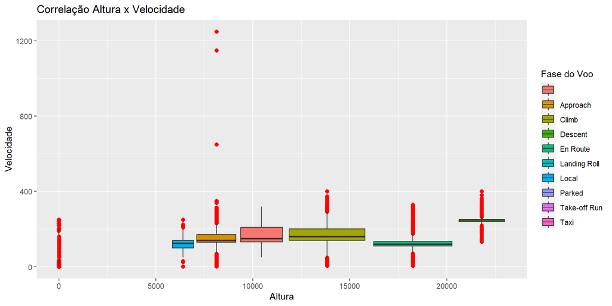

```r
#Grafico de Correlação entre altura e velocidade, mas nao acho que esse seja bom, pois são duas variaveis quantitativas
def_strikes %>%
  ggplot(aes(x=HEIGHT , y=SPEED, fill=PHASE_OF_FLIGHT)) + geom_boxplot(outlier.color = "red", outlier.size = 2, outlier.fill="red") + labs(title = "Correlação Altura x Velocidade", x="Altura", y="Velocidade", fill="Fase do Voo")
```

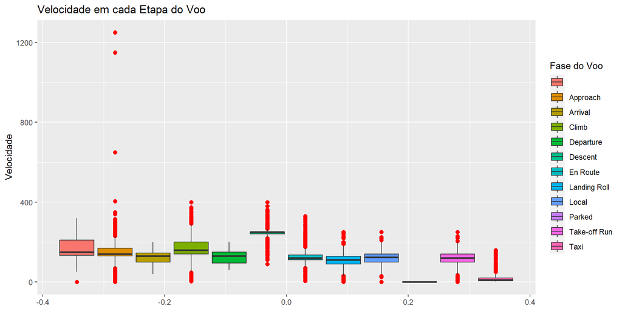

```r
#Boxplot da velocidade em cada etapa do Voo
def_strikes %>%
  ggplot(aes(y=SPEED, fill=PHASE_OF_FLIGHT)) + geom_boxplot(outlier.color = "red", outlier.size = 2, outlier.fill="red") + labs(title = "Velocidade em cada Etapa do Voo", y="Velocidade", fill="Fase do Voo")
```

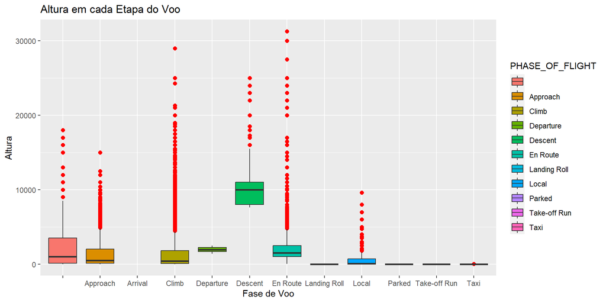

```r
#Altura em cada fase de voo"
def_strikes %>%
  ggplot(aes(x=PHASE_OF_FLIGHT, y=HEIGHT, fill=PHASE_OF_FLIGHT)) + geom_boxplot(outlier.color = "red", outlier.size = 2, outlier.fill="red") + labs(title = "Altura em cada Etapa do Voo", y="Altura", x = "Fase de Voo")
```

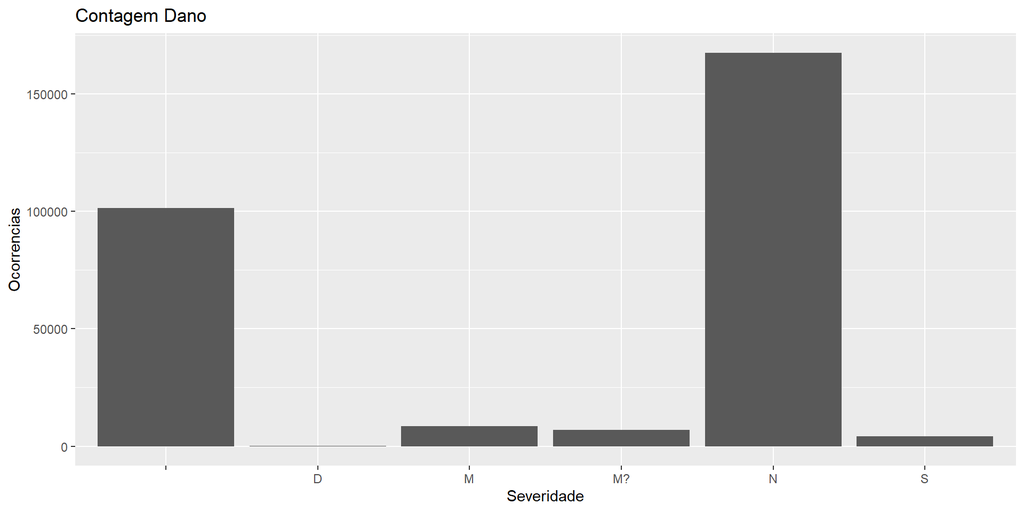

```r
#Grafico de Barras do dano, o fill por AC_Mass nao esta funcionando
def_strikes %>%
  ggplot(aes(x= DAMAGE_LEVEL, fill =AC_MASS)) + geom_bar() + labs(title="Contagem Dano", x="Severidade", y="Ocorrencias")
```

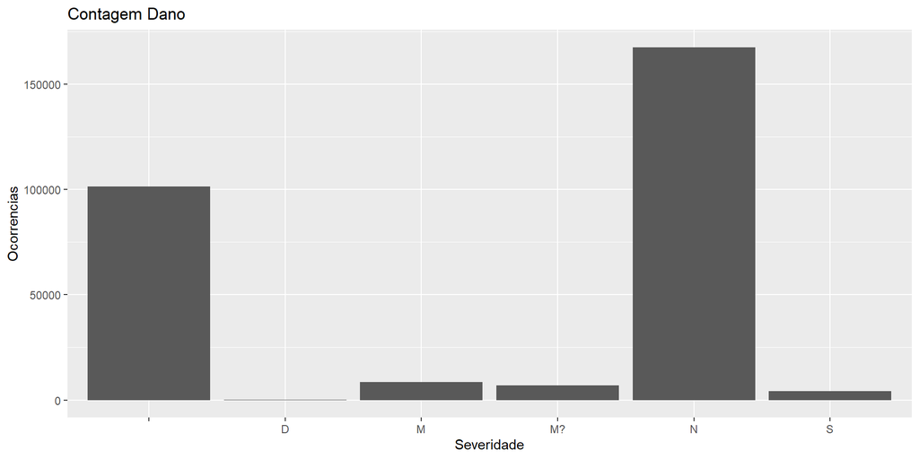

```r
#Contagem da severidade dos impactos
def_strikes %>%
  ggplot(aes(x= DAMAGE_LEVEL)) + geom_bar() + labs(title="Contagem Dano", x="Severidade", y="Ocorrencias")
```

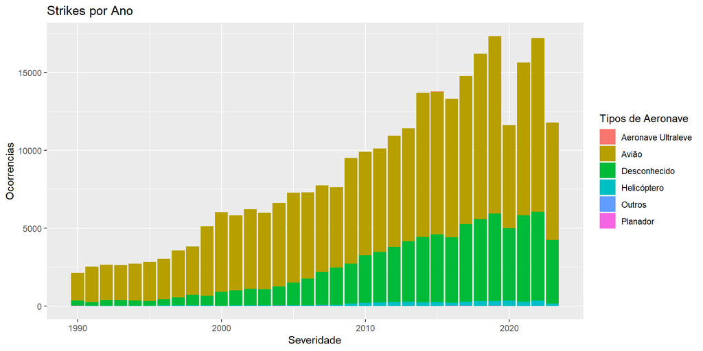

```r
#Anos e batidas de aeronave, fazer a sem os unknow/desconhecidos tambem mais para frente
def_strikes %>%
  ggplot(aes(x= INCIDENT_YEAR, fill = Tipo_de_Aeronave)) + geom_bar() + labs(title="Strikes por Ano", x="Severidade", y="Ocorrencias", fill="Tipos de Aeronave")
```

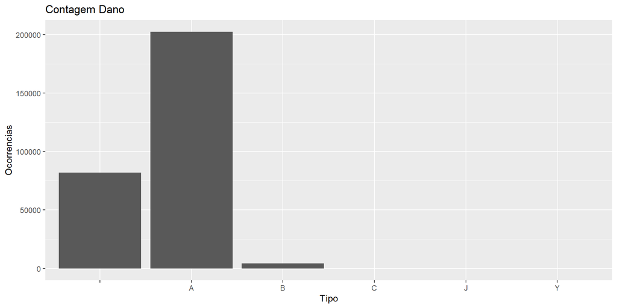

```r
#teste para ver se a mudanca de nome esta entregando os mesmos resultados para a contagem de ocorrencias com cada tipo de aeronave
def_strikes %>%
  ggplot(aes(x= AC_CLASS)) + geom_bar() + labs(title="Contagem Dano", x="Tipo", y="Ocorrencias")
```

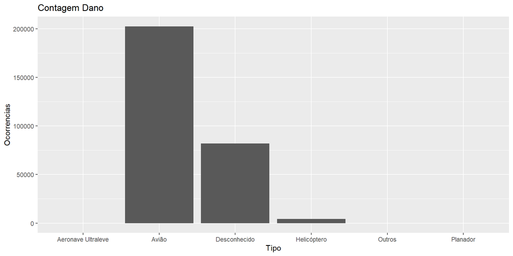

```r
def_strikes %>%
  ggplot(aes(x= Tipo_de_Aeronave)) + geom_bar() + labs(title="Contagem Dano", x="Tipo", y="Ocorrencias")
```

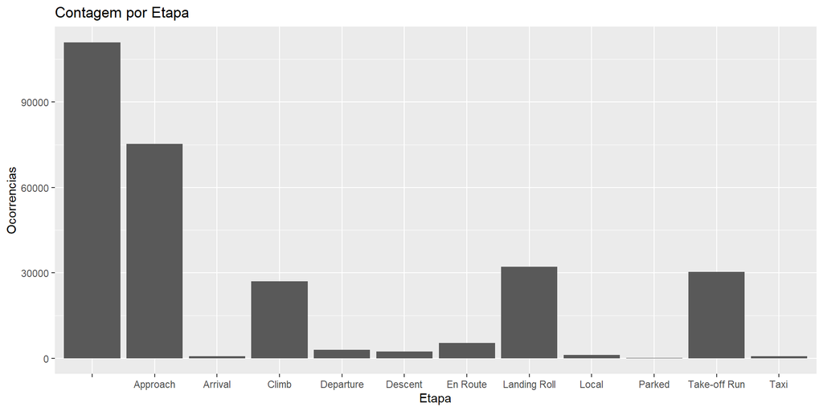

```r
#QUal etapa do Voo tem mais batidas, com isso percebemos que quanto mais baixo mais bate, o que é logico, porque as avez nao voam super alto
def_strikes %>%
  ggplot(aes(x= PHASE_OF_FLIGHT)) + geom_bar() + labs(title="Contagem por Etapa", x="Etapa", y="Ocorrencias")
```

```r
#def_strikes %>%
#  gg(plot)

#def_strikes %>%
```